# Ensemble Techniques - Term Deposit Subscription Prediction_Arman

## Ensemble Techniques - Term Deposit Subscription Prediction

#### Data Description

The historical data for this project is available in file

https://archive.ics.uci.edu/ml/datasets/Bank+Marketing

#### Attribute information

Input variables:

#### Bank client data:

```
1. age: Continuous feature
2. job: Type of job (management, technician, entrepreneur, blue-collar, etc.)
3. marital: marital status (married, single, divorced)
4. education: education level (primary, secondary, tertiary)
5. default: has credit in default?
6. housing: has housing loan?
7. loan: has personal loan?
8. balance in account
```

#### Related to previous contact:

```
9. contact: contact communication type
10. month: last contact month of year
11. day: last contact day of the month
12. duration: last contact duration, in seconds
```

#### Other attributes:

```
13. campaign: number of contacts performed during this campaign and for this
client
14. pdays: number of days that passed by after the client was last contacted from a
previous campaign (-1 tells us the person has not been contacted or contact
period is beyond 900 days)
15. previous: number of contacts performed before this campaign and for this
client
16. poutcome: outcome of the previous marketing campaign
```

#### Output variable (desired target):

```
17. Target: Tell us has the client subscribed a term deposit. (Yes, No)
```

### Import Libraries and load dataset

```python
import pandas as pd
import numpy as np
from sklearn import metrics
import matplotlib.pyplot as plt
%matplotlib inline
import seaborn as sns
from sklearn.model_selection import train_test_split
from sklearn.tree import DecisionTreeClassifier
#from sklearn.feature_extraction.text import CountVectorizer  #DT does not take strings as input for the model fit step....
from IPython.display import Image
#import pydotplus as pydot
from sklearn import tree
from os import system
```

```python
termDeposit = pd.read_csv("bank-full.csv") #create data drame to read data set
```

### Deliverable 1: (Exploratory data quality report)

#### Univariate analysis

```python
# Print 10 samples from the dataset
termDeposit.head(10)
```

|  | age | job | marital | education | default | balance | housing | loan | contact | day | month | duration | campaign | pdays | previous | poutcome | Target |
| --- | --- | --- | --- | --- | --- | --- | --- | --- | --- | --- | --- | --- | --- | --- | --- | --- | --- |
| 0 | 58 | management | married | tertiary | no | 2143 | yes | no | unknown | 5 | may | 261 | 1 | -1 | 0 | unknown | no |
| 1 | 44 | technician | single | secondary | no | 29 | yes | no | unknown | 5 | may | 151 | 1 | -1 | 0 | unknown | no |
| 2 | 33 | entrepreneur | married | secondary | no | 2 | yes | yes | unknown | 5 | may | 76 | 1 | -1 | 0 | unknown | no |
| 3 | 47 | blue-collar | married | unknown | no | 1506 | yes | no | unknown | 5 | may | 92 | 1 | -1 | 0 | unknown | no |
| 4 | 33 | unknown | single | unknown | no | 1 | no | no | unknown | 5 | may | 198 | 1 | -1 | 0 | unknown | no |
| 5 | 35 | management | married | tertiary | no | 231 | yes | no | unknown | 5 | may | 139 | 1 | -1 | 0 | unknown | no |
| 6 | 28 | management | single | tertiary | no | 447 | yes | yes | unknown | 5 | may | 217 | 1 | -1 | 0 | unknown | no |
| 7 | 42 | entrepreneur | divorced | tertiary | yes | 2 | yes | no | unknown | 5 | may | 380 | 1 | -1 | 0 | unknown | no |
| 8 | 58 | retired | married | primary | no | 121 | yes | no | unknown | 5 | may | 50 | 1 | -1 | 0 | unknown | no |
| 9 | 43 | technician | single | secondary | no | 593 | yes | no | unknown | 5 | may | 55 | 1 | -1 | 0 | unknown | no |

```python
# find number of rows and column
termDeposit.shape
```

```
(45211, 17)
```

```python
# describe df numerical columns
termDeposit.describe().T
```

|  | count | mean | std | min | 25% | 50% | 75% | max |
| --- | --- | --- | --- | --- | --- | --- | --- | --- |
| age | 45211.0 | 40.936210 | 10.618762 | 18.0 | 33.0 | 39.0 | 48.0 | 95.0 |
| balance | 45211.0 | 1362.272058 | 3044.765829 | -8019.0 | 72.0 | 448.0 | 1428.0 | 102127.0 |
| day | 45211.0 | 15.806419 | 8.322476 | 1.0 | 8.0 | 16.0 | 21.0 | 31.0 |
| duration | 45211.0 | 258.163080 | 257.527812 | 0.0 | 103.0 | 180.0 | 319.0 | 4918.0 |
| campaign | 45211.0 | 2.763841 | 3.098021 | 1.0 | 1.0 | 2.0 | 3.0 | 63.0 |
| pdays | 45211.0 | 40.197828 | 100.128746 | -1.0 | -1.0 | -1.0 | -1.0 | 871.0 |
| previous | 45211.0 | 0.580323 | 2.303441 | 0.0 | 0.0 | 0.0 | 0.0 | 275.0 |

#### Insights

The 75% score of age, balance, duration, compaign, pdays and previous have some outliers indicate that the data is skewed or outliers are present in the data

```python
numerical_variabless = termDeposit.dtypes[termDeposit.dtypes == np.int64]
listOfnumerical_variables = list(numerical_variabless.index)
df_numerical_variabless = termDeposit[listOfnumerical_variables]

df_numerical_variabless.head(10)
```

|  | age | balance | day | duration | campaign | pdays | previous |
| --- | --- | --- | --- | --- | --- | --- | --- |
| 0 | 58 | 2143 | 5 | 261 | 1 | -1 | 0 |
| 1 | 44 | 29 | 5 | 151 | 1 | -1 | 0 |
| 2 | 33 | 2 | 5 | 76 | 1 | -1 | 0 |
| 3 | 47 | 1506 | 5 | 92 | 1 | -1 | 0 |
| 4 | 33 | 1 | 5 | 198 | 1 | -1 | 0 |
| 5 | 35 | 231 | 5 | 139 | 1 | -1 | 0 |
| 6 | 28 | 447 | 5 | 217 | 1 | -1 | 0 |
| 7 | 42 | 2 | 5 | 380 | 1 | -1 | 0 |
| 8 | 58 | 121 | 5 | 50 | 1 | -1 | 0 |
| 9 | 43 | 593 | 5 | 55 | 1 | -1 | 0 |

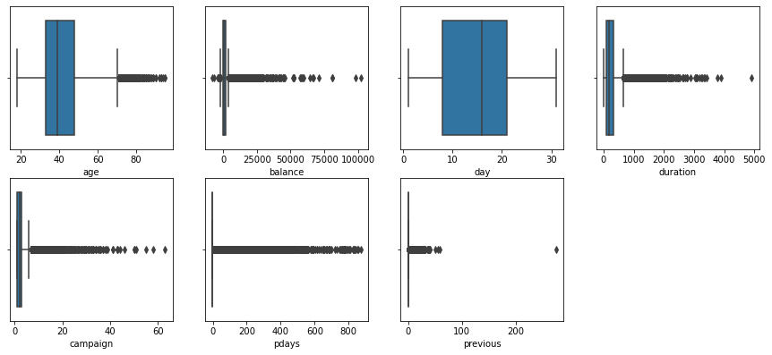

```python
#Find Outliers in numerical features

#boxplot on numerical features to find outliers
plt.figure(figsize=(15,10))
plotnumber =1
for numerical_variable in df_numerical_variabless:
    plt.subplot(3,4,plotnumber)
    sns.boxplot(termDeposit[numerical_variable])
    plotnumber+=1

plt.show()
```

#### Insights

Age, balance, duration, compaign, pdays and previous have some outliers

### Outlier Treatment

```python
col_names=['age', 'balance', 'day', 'duration', 'campaign', 'pdays', 'previous']

display(col_names)

for i in col_names:
    q1, q2, q3 = termDeposit[i].quantile([0.25,0.5,0.75])
    IQR = q3 - q1
    lower_cap=q1-1.5*IQR
    upper_cap=q3+1.5*IQR
    termDeposit[i]=termDeposit[i].apply(lambda x: upper_cap if x>(upper_cap) else (lower_cap if x<(lower_cap) else x))
```

```
['age', 'balance', 'day', 'duration', 'campaign', 'pdays', 'previous']
```

```python
# describe df numerical columns
termDeposit.describe().T
```

|  | count | mean | std | min | 25% | 50% | 75% | max |
| --- | --- | --- | --- | --- | --- | --- | --- | --- |
| age | 45211.0 | 40.868185 | 10.394895 | 18.0 | 33.0 | 39.0 | 48.0 | 70.5 |
| balance | 45211.0 | 933.706974 | 1176.765369 | -1962.0 | 72.0 | 448.0 | 1428.0 | 3462.0 |
| day | 45211.0 | 15.806419 | 8.322476 | 1.0 | 8.0 | 16.0 | 21.0 | 31.0 |
| duration | 45211.0 | 234.939307 | 176.749932 | 0.0 | 103.0 | 180.0 | 319.0 | 643.0 |
| campaign | 45211.0 | 2.392228 | 1.600111 | 1.0 | 1.0 | 2.0 | 3.0 | 6.0 |
| pdays | 45211.0 | -1.000000 | 0.000000 | -1.0 | -1.0 | -1.0 | -1.0 | -1.0 |
| previous | 45211.0 | 0.000000 | 0.000000 | 0.0 | 0.0 | 0.0 | 0.0 | 0.0 |

#### Insights

The 75% score of age, balance, duration, compaign, pdays and previous indicate there is no outliers

```python
# check the df structe
termDeposit.info()
```

```
<class 'pandas.core.frame.DataFrame'>
RangeIndex: 45211 entries, 0 to 45210
Data columns (total 17 columns):
 #   Column     Non-Null Count  Dtype
---  ------     --------------  -----
 0   age        45211 non-null  float64
 1   job        45211 non-null  object
 2   marital    45211 non-null  object
 3   education  45211 non-null  object
 4   default    45211 non-null  object
 5   balance    45211 non-null  float64
 6   housing    45211 non-null  object
 7   loan       45211 non-null  object
 8   contact    45211 non-null  object
 9   day        45211 non-null  int64
 10  month      45211 non-null  object
 11  duration   45211 non-null  float64
 12  campaign   45211 non-null  float64
 13  pdays      45211 non-null  float64
 14  previous   45211 non-null  float64
 15  poutcome   45211 non-null  object
 16  Target     45211 non-null  object
dtypes: float64(6), int64(1), object(10)
memory usage: 5.9+ MB
```

#### Insights

Many columns are of type object i.e. strings. These need to be converted to ordinal type.

Convert the columns with an 'object' datatype into categorical variables

```python
for feature in termDeposit.columns: # Loop through all columns in the dataframe
    if termDeposit[feature].dtype == 'object': # Only apply for columns with categorical strings
        termDeposit[feature] = pd.Categorical(termDeposit[feature])# Replace strings with an integer
termDeposit['previous'].unique()
```

```
array([0.])
```

```python
# find missing values
features_na = [features for features in termDeposit.columns if termDeposit[features].isnull().sum() > 0]
for feature in features_na:
    print(feature, np.round(termDeposit[feature].isnull().mean(), 4),  ' % missing values')
else:
    print("No missing value found")
```

```
No missing value found
```

```python
for col in termDeposit.select_dtypes(include='category').columns:
    print(col)
    print(termDeposit[col].unique())
```

```
job
[management, technician, entrepreneur, blue-collar, unknown, ..., services, self-employed, unemployed, housemaid, student]
Length: 12
Categories (12, object): [management, technician, entrepreneur, blue-collar, ..., self-employed, unemployed, housemaid, student]
marital
[married, single, divorced]
Categories (3, object): [married, single, divorced]
education
[tertiary, secondary, unknown, primary]
Categories (4, object): [tertiary, secondary, unknown, primary]
default
[no, yes]
Categories (2, object): [no, yes]
housing
[yes, no]
Categories (2, object): [yes, no]
loan
[no, yes]
Categories (2, object): [no, yes]
contact
[unknown, cellular, telephone]
Categories (3, object): [unknown, cellular, telephone]
month
[may, jun, jul, aug, oct, ..., jan, feb, mar, apr, sep]
Length: 12
Categories (12, object): [may, jun, jul, aug, ..., feb, mar, apr, sep]
poutcome
[unknown, failure, other, success]
Categories (4, object): [unknown, failure, other, success]
Target
[no, yes]
Categories (2, object): [no, yes]
```

#### Find Categorical Feature Distribution

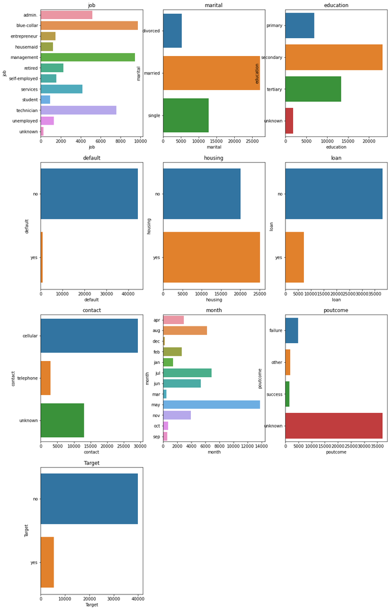

```python
#check count based on categorical features
plt.figure(figsize=(15,80), facecolor='white')
plotnumber =1

for categorical_feature in termDeposit.select_dtypes(include='category').columns:
    ax = plt.subplot(12,3,plotnumber)
    sns.countplot(y=categorical_feature,data=termDeposit)
    plt.xlabel(categorical_feature)
    plt.title(categorical_feature)
    plotnumber+=1
plt.show()
```

#### Insights

- Client with job type as management records and blue color are high in given dataset and unknown are very less
- Client who married are high in records in given dataset and divorced are less
- Client whoes education background is secondary are in high numbers in given dataset
- Defualt feature seems to be does not play importand role as it has value of no at high ratio to value yes which can drop
- Data in month of may is high and less in dec

### Check the class balance/imbalance

```
no     0.883015
yes    0.116985
Name: Target, dtype: float64
```

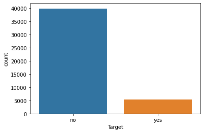

```python
#levels of Y variable
print(termDeposit['Target'].value_counts(normalize=True))
sns.countplot(x='Target',data=termDeposit)
plt.show()
```

Take-away:

given dataset seems to be imbalanced.This shows the small fraction of positive yes samples.

```python
#Check target label split over categorical features and find the count
for categorical_feature in termDeposit.select_dtypes(include='category').columns:
    print(termDeposit.groupby(['Target',categorical_feature]).size())
```

```
Target  job
no      admin.           4540
        blue-collar      9024
        entrepreneur     1364
        housemaid        1131
        management       8157
        retired          1748
        self-employed    1392
        services         3785
        student           669
        technician       6757
        unemployed       1101
        unknown           254
yes     admin.            631
        blue-collar       708
        entrepreneur      123
        housemaid         109
        management       1301
        retired           516
        self-employed     187
        services          369
        student           269
        technician        840
        unemployed        202
        unknown            34
dtype: int64
Target  marital
no      divorced     4585
        married     24459
        single      10878
yes     divorced      622
        married      2755
        single       1912
dtype: int64
Target  education
no      primary       6260
        secondary    20752
        tertiary     11305
        unknown       1605
yes     primary        591
```

[output cut: 57 more lines]

```
no      failure      4283
        other        1533
        success       533
        unknown     33573
yes     failure       618
        other         307
        success       978
        unknown      3386
dtype: int64
Target  Target
no      no        39922
        yes           0
yes     no            0
        yes        5289
dtype: int64
```

#### Insights

- Management client has high interest on deposit
- Client who has housing loan seems to be not interested much on deposit
- If pre campagin outcome that is poutcome=success then, there is high chance of client to show interest on deposit
- In month of May, Aug and July, client show high interest to deposit

```python
print(termDeposit.groupby(['Target','pdays']).size())
print(termDeposit['pdays'].unique())
```

```
Target  pdays
no      -1.0     39922
yes     -1.0      5289
dtype: int64
[-1.]
```

```python
# drop pdays as it has all -1 value
termDeposit.drop(['pdays'],axis=1, inplace=True)
```

```python
#defaut features does not play imp role
termDeposit.groupby(['Target','default']).size()
```

```
Target  default
no      no         39159
        yes          763
yes     no          5237
        yes           52
dtype: int64
```

```python
# drop pdays as it has all -1 value
termDeposit.drop(['default'],axis=1, inplace=True)
```

```python
#Previous column has only one value
termDeposit['previous'].unique()
```

```
array([0.])
```

```python
#drop previous column as only one value

termDeposit.drop(['previous'],axis=1, inplace=True)
```

### Multivariate analysis

#### Understanding relationship between different variables

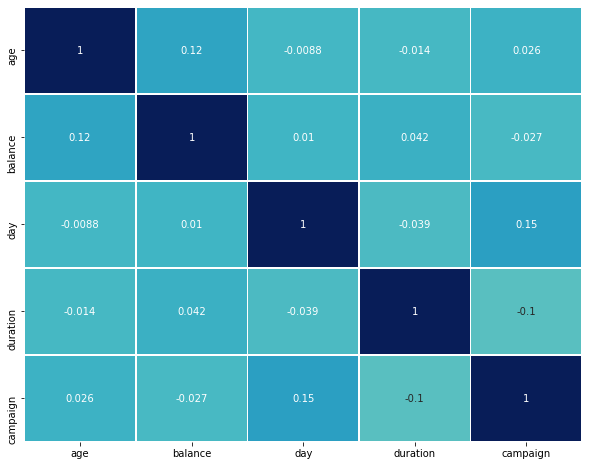

```python
plt.figure(figsize=(10,8))
sns.heatmap(termDeposit.corr(),
            annot=True,
            linewidths=.5,
            center=0,
            cbar=False,
            cmap="YlGnBu")
plt.show()
```

#### Take-away:

it seems no feature is heavily correlated with other features

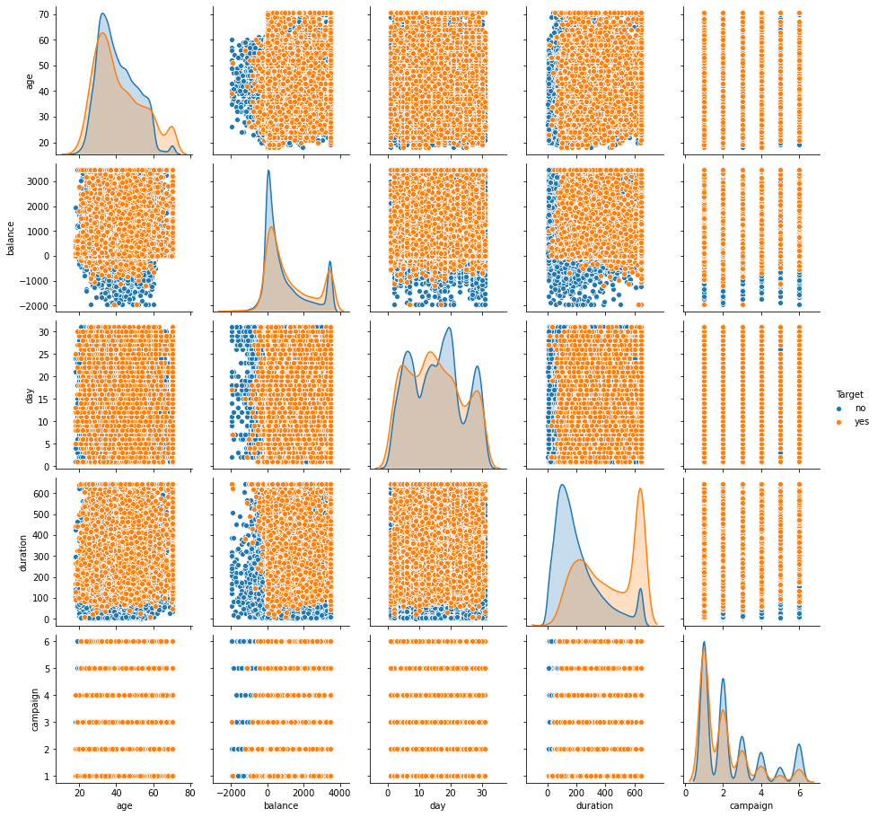

```python
sns.pairplot(termDeposit, hue='Target')
```

#### Insights

```python
#Copy term deposit in new data frame
df4=termDeposit.copy()
```

## Deliverable – 2 (Prepare the data for analytics)

```python
#One hot encoding
cat_columns = ['job', 'marital', 'education', 'contact', 'month', 'poutcome', 'Target', 'housing', 'loan']
for col in  cat_columns:
    df4 = pd.concat([df4.drop(col, axis=1),pd.get_dummies(df4[col], prefix=col, prefix_sep='_',drop_first=True, dummy_na=False)], axis=1)
```

```python
#Checking one hot encoding
df4.head(10)
```

|  | age | balance | day | duration | campaign | job_blue-collar | job_entrepreneur | job_housemaid | job_management | job_retired | ... | month_may | month_nov | month_oct | month_sep | poutcome_other | poutcome_success | poutcome_unknown | Target_yes | housing_yes | loan_yes |
| --- | --- | --- | --- | --- | --- | --- | --- | --- | --- | --- | --- | --- | --- | --- | --- | --- | --- | --- | --- | --- | --- |
| 0 | 58.0 | 2143.0 | 5 | 261.0 | 1.0 | 0 | 0 | 0 | 1 | 0 | ... | 1 | 0 | 0 | 0 | 0 | 0 | 1 | 0 | 1 | 0 |
| 1 | 44.0 | 29.0 | 5 | 151.0 | 1.0 | 0 | 0 | 0 | 0 | 0 | ... | 1 | 0 | 0 | 0 | 0 | 0 | 1 | 0 | 1 | 0 |
| 2 | 33.0 | 2.0 | 5 | 76.0 | 1.0 | 0 | 1 | 0 | 0 | 0 | ... | 1 | 0 | 0 | 0 | 0 | 0 | 1 | 0 | 1 | 1 |
| 3 | 47.0 | 1506.0 | 5 | 92.0 | 1.0 | 1 | 0 | 0 | 0 | 0 | ... | 1 | 0 | 0 | 0 | 0 | 0 | 1 | 0 | 1 | 0 |
| 4 | 33.0 | 1.0 | 5 | 198.0 | 1.0 | 0 | 0 | 0 | 0 | 0 | ... | 1 | 0 | 0 | 0 | 0 | 0 | 1 | 0 | 0 | 0 |
| 5 | 35.0 | 231.0 | 5 | 139.0 | 1.0 | 0 | 0 | 0 | 1 | 0 | ... | 1 | 0 | 0 | 0 | 0 | 0 | 1 | 0 | 1 | 0 |
| 6 | 28.0 | 447.0 | 5 | 217.0 | 1.0 | 0 | 0 | 0 | 1 | 0 | ... | 1 | 0 | 0 | 0 | 0 | 0 | 1 | 0 | 1 | 1 |
| 7 | 42.0 | 2.0 | 5 | 380.0 | 1.0 | 0 | 1 | 0 | 0 | 0 | ... | 1 | 0 | 0 | 0 | 0 | 0 | 1 | 0 | 1 | 0 |
| 8 | 58.0 | 121.0 | 5 | 50.0 | 1.0 | 0 | 0 | 0 | 0 | 1 | ... | 1 | 0 | 0 | 0 | 0 | 0 | 1 | 0 | 1 | 0 |
| 9 | 43.0 | 593.0 | 5 | 55.0 | 1.0 | 0 | 0 | 0 | 0 | 0 | ... | 1 | 0 | 0 | 0 | 0 | 0 | 1 | 0 | 1 | 0 |

10 rows × 40 columns

```python
X = df4.drop("Target_yes" , axis=1)
y = df4.pop("Target_yes")
```

```python
# Split Dataset into Training set and Test set¶

from sklearn.model_selection import train_test_split
X_train, X_test, y_train, y_test = train_test_split(X,y,test_size=0.30, random_state=0)
```